# The harm and impact of floods on humans

Wuge Li

2023-10-31

Background of the project

Floods are widely recognized as one of the most devastating natural disasters in the U.S. I aim to delve deeper into the dangers posed by floods, the economic implications of these events, and to discern any patterns regarding the communities most impacted by them. To address these queries, I will be utilizing a dataset spanning the years 2020 to 2021, sourced from NOAA.

The first step I need to do is to read the data.

```r
d_2020 <- read.csv("StormEvents_details-ftp_v1.0_d2020_c20230927.csv", header = T)
d_2021 <- read.csv("StormEvents_details-ftp_v1.0_d2021_c20231017.csv", header = T)

f_2020 <- read.csv("StormEvents_fatalities-ftp_v1.0_d2020_c20230927.csv", header = T)
f_2021 <- read.csv("StormEvents_fatalities-ftp_v1.0_d2021_c20231017.csv", header = T)
l_2020 <- read.csv("StormEvents_locations-ftp_v1.0_d2020_c20230927.csv", header = T)
l_2021 <- read.csv("StormEvents_locations-ftp_v1.0_d2021_c20231017.csv", header = T)

diaster <- read.csv("DisasterDeclarationsSummaries.csv", header = T)
sum <- read.csv("FemaWebDisasterSummaries.csv", header = T)
```

In my view, column names are crucial to understanding a data. They provide insights into the content and context of the data.

```r
colnames(d_2020)
```

```
##  [1] "BEGIN_YEARMONTH"    "BEGIN_DAY"          "BEGIN_TIME"
##  [4] "END_YEARMONTH"      "END_DAY"            "END_TIME"
##  [7] "EPISODE_ID"         "EVENT_ID"           "STATE"
## [10] "STATE_FIPS"         "YEAR"               "MONTH_NAME"
## [13] "EVENT_TYPE"         "CZ_TYPE"            "CZ_FIPS"
## [16] "CZ_NAME"            "WFO"                "BEGIN_DATE_TIME"
## [19] "CZ_TIMEZONE"        "END_DATE_TIME"      "INJURIES_DIRECT"
## [22] "INJURIES_INDIRECT"  "DEATHS_DIRECT"      "DEATHS_INDIRECT"
## [25] "DAMAGE_PROPERTY"    "DAMAGE_CROPS"       "SOURCE"
## [28] "MAGNITUDE"          "MAGNITUDE_TYPE"     "FLOOD_CAUSE"
## [31] "CATEGORY"           "TOR_F_SCALE"        "TOR_LENGTH"
## [34] "TOR_WIDTH"          "TOR_OTHER_WFO"      "TOR_OTHER_CZ_STATE"
## [37] "TOR_OTHER_CZ_FIPS"  "TOR_OTHER_CZ_NAME"  "BEGIN_RANGE"
## [40] "BEGIN_AZIMUTH"      "BEGIN_LOCATION"     "END_RANGE"
## [43] "END_AZIMUTH"        "END_LOCATION"       "BEGIN_LAT"
## [46] "BEGIN_LON"          "END_LAT"            "END_LON"
## [49] "EPISODE_NARRATIVE"  "EVENT_NARRATIVE"    "DATA_SOURCE"
```

In this data, it’s talking about

1. the impact of natural disasters in 2020.
2. It shows when the disasters begin and end. (exact time)
3. Where the disasters happen. (State, begin and end location, begin and end longitude and latitude)
4. What kind of the disasters happened. (For example, Thunderstorm Wind, flood and so on)
5. Damages that the disasters lead. (injury direct and indirect, deaths direct and indirect, damage property and crops)

Since, column names for both d_2020 and d_2021 are the same, so I only show the column names of d_2020 here  
Clean, tidy and show the data

The next step we need to do is to tidy the data.

Initially, I discovered that the data encompasses various disaster types. However, my interest lies solely in flood-related incidents, so I employed a filter to isolate all flood events.

```r
tidy_d_2020 <- d_2020 |>
  filter(str_detect(string = EVENT_TYPE, pattern = "(?i)flood"))

tidy_d_2021 <- d_2021 |>
  filter(str_detect(string = EVENT_TYPE, pattern = "(?i)flood"))

unique(tidy_d_2020$EVENT_TYPE)
```

```
## [1] "Flash Flood"     "Flood"           "Coastal Flood"   "Lakeshore Flood"
```

After applying the filter, I used a unique function to examine the residual event types and determined that they all pertained to floods.  
Next, we aim to determine the number of flood events that occurred in the years 2020 and 2021.

```r
total_floods_2020 <- nrow(tidy_d_2020)
total_floods_2021 <- nrow(tidy_d_2021)
total_floods_2020
```

```
## [1] 6602
```

```r
total_floods_2021
```

```
## [1] 7059
```

Utilizing the nrow function, it was determined that there were 6,602 flood incidents in 2020, and 7,059 flood incidents in 2021.  
Not all flood events result in significant damage. Therefore, I aim to ascertain the number of floods that qualified as disasters. To do this, I will refer to the disaster form data that I have previously reviewed.

```r
tidy_disaster2020 <- diaster |>
  filter(fyDeclared == 2020) |>
  filter(incidentType == "Flood")
unique(tidy_disaster2020$disasterNumber)
```

```
## [1] 4553 4539 4519 4477 4475 4466
```

```r
disaster_floods_2020 <- length(unique(tidy_disaster2020$disasterNumber))
disaster_floods_2020
```

```
## [1] 6
```

```r
tidy_disaster2021 <- diaster |>
  filter(fyDeclared == 2021) |>
  filter(incidentType == "Flood")
unique(tidy_disaster2021$disasterNumber)
```

```
## [1] 4621 4620 4609 4606 4605 4604 4595 4571
```

```r
disaster_floods_2021 <- length(unique(tidy_disaster2021$disasterNumber))
disaster_floods_2021
```

```
## [1] 8
```

I organized the disaster form data and applied the unique function. It was revealed that there were only 6 flood events classified as disasters in 2020 and 8 such events in 2021.

```r
percentage_2020 <- (disaster_floods_2020 / total_floods_2020) * 100
percentage_2021 <- (disaster_floods_2021 / total_floods_2021) * 100


print(paste0(percentage_2020, "%"))
```

```
## [1] "0.0908815510451378%"
```

```r
print(paste0(percentage_2021, "%"))
```

```
## [1] "0.113330500070832%"
```

Upon calculating the percentages, it was found that only 0.09% of flood events in 2020 were classified as disasters, and for 2021, the figure was slightly higher at 0.11%.  
I want to create a graph to display the areas affected by flood disasters in 2020 and 2021.

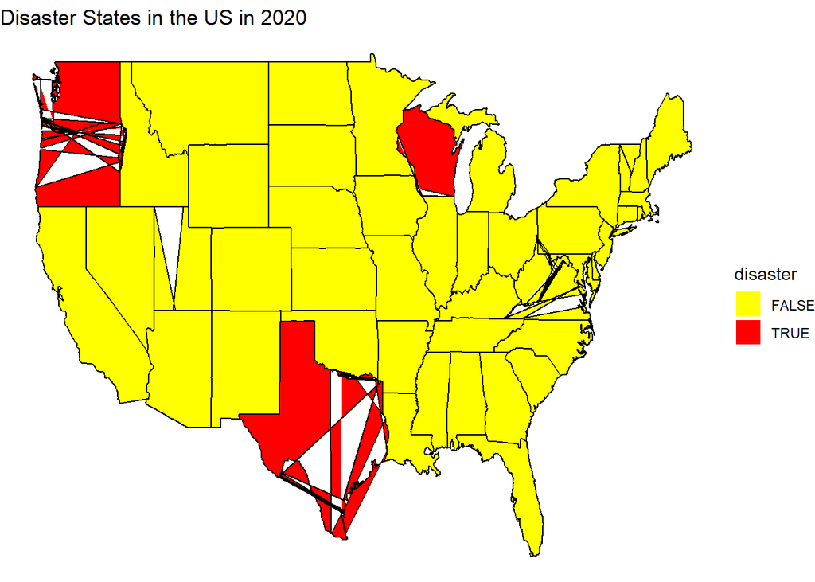

```r
disaster_data <- tidy_disaster2020

disaster_data$disaster <- TRUE

disaster_data_unique <- aggregate(disaster ~ state, data = disaster_data, FUN = any)

state_names <- c(ND = "north nakota", OR = "oregon", TX = "texas", WA = "washington", WI = "wisconsin")

disaster_data_unique <- disaster_data_unique |>
  mutate(state = state_names[state])

us_map <- map_data("state")

map_data <- merge(us_map, disaster_data_unique, by.x = "region", by.y = "state", all.x = TRUE)

map_data$disaster[is.na(map_data$disaster)] <- FALSE

ggplot(data = map_data, aes(x = long, y = lat, group = group, fill = disaster)) +
  geom_polygon(color = "white") +
  geom_path() +
  scale_fill_manual(values = c("FALSE" = "yellow", "TRUE" = "red")) +
  labs(title = "Disaster States in the US in 2020") +
  theme_void()
```

This graph illustrates that the majority of flood disasters which happened in 2020 occurred predominantly in:

Washington, located in the upper left corner

Texas at the bottom center

Wisconsin at the upper right of the map.  
Then we looked at the flood disaster at 2021.

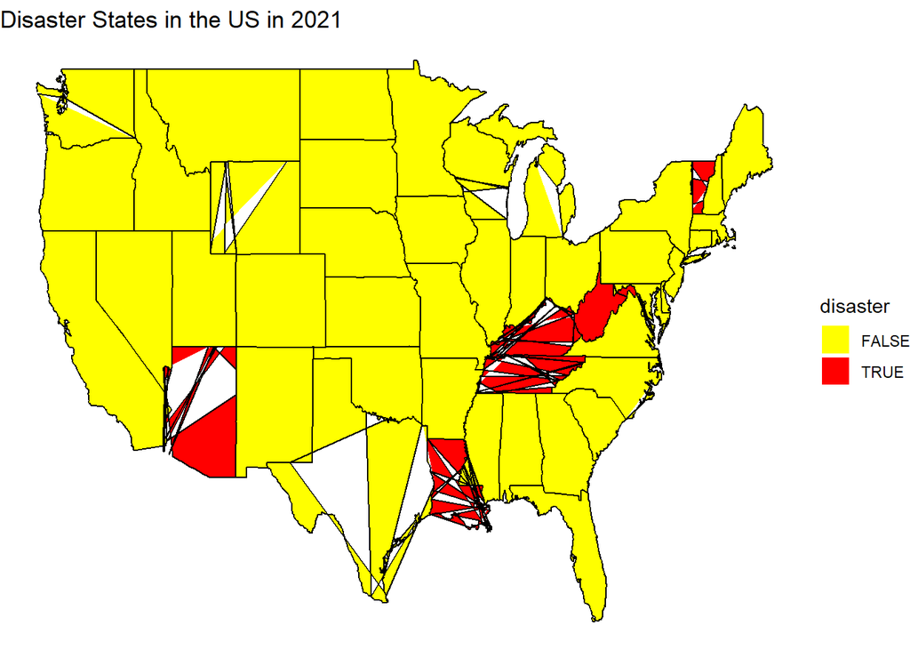

```r
disaster_data <- tidy_disaster2021

disaster_data$disaster <- TRUE

disaster_data_unique <- aggregate(disaster ~ state, data = disaster_data, FUN = any)

state_names <- c(AZ = "arizona", HI = "hawaii", KY = "kentucky", LA = "louisiana",
                 PR = "puerto rico", TN = "tennessee", VT = "vermont", WV = "west virginia")

disaster_data_unique <- disaster_data_unique |>
  mutate(state = state_names[state])

us_map <- map_data("state")

map_data <- merge(us_map, disaster_data_unique, by.x = "region", by.y = "state", all.x = TRUE)

map_data$disaster[is.na(map_data$disaster)] <- FALSE

ggplot(data = map_data, aes(x = long, y = lat, group = group, fill = disaster)) +
  geom_polygon(color = "white") +
  geom_path() +
  scale_fill_manual(values = c("FALSE" = "yellow", "TRUE" = "red")) +
  labs(title = "Disaster States in the US in 2021") +
  theme_void()
```

This graph illustrates that the majority of flood disasters which happened in 2021 occurred predominantly in:

Arizona, located in the bottom left

Louisiana at the bottom right

Kentucky, Tennessee and West Virginia at the middle right of the map

Vermont at the upper right corner of the map.  
Then, I want to focus on the influence of these flood disasters. I will use the Disaster Summaries form  
This is the description of the form

```r
data_fields <- data.frame(
  Name = c(
    "disasterNumber",
    "totalNumberIaApproved",
    "totalAmountIhpApproved",
    "totalAmountHaApproved",
    "totalAmountOnaApproved",
    "totalObligatedAmountPa",
    "totalObligatedAmountCatAb",
    "totalObligatedAmountCatC2g",
    "paLoadDate",
    "iaLoadDate",
    "totalObligatedAmountHmgp",
    "hash",
    "lastRefresh",
    "id"
  ),
  Description = c(
    "A number which show the unique disaster",
    "The number of disaster approved applications for IA",
    "Dollars approved for IHP",
    "Dollars approved for Housing Assistance",
    "Dollars approved for Other Needs Assistance",
    "Dollars available for Public Assistance grants",
    "Dollars for Emergency Work Public Assistance (Categories A & B)",
    "Dollars for Permanent Work Public Assistance (Categories C to G)",
    "Date PA data was updated",
    "Date IA data was updated",
    "Dollars obligated for the Hazard Mitigation Grant Program",
    "MD5 hash of fileds and values of the record",
    "Date the record was last updated",
    "Unique ID assigned to the record"
  ),
  stringsAsFactors = FALSE
)

kable(data_fields, format = "html", caption = "Data Fields Description") %>%
  kable_styling(bootstrap_options = c("striped", "hover", "condensed"), full_width = F)
```

Data Fields Description

| Name | Description |
| --- | --- |
| disasterNumber | A number which show the unique disaster |
| totalNumberIaApproved | The number of disaster approved applications for IA |
| totalAmountIhpApproved | Dollars approved for IHP |
| totalAmountHaApproved | Dollars approved for Housing Assistance |
| totalAmountOnaApproved | Dollars approved for Other Needs Assistance |
| totalObligatedAmountPa | Dollars available for Public Assistance grants |
| totalObligatedAmountCatAb | Dollars for Emergency Work Public Assistance (Categories A & B) |
| totalObligatedAmountCatC2g | Dollars for Permanent Work Public Assistance (Categories C to G) |
| paLoadDate | Date PA data was updated |
| iaLoadDate | Date IA data was updated |
| totalObligatedAmountHmgp | Dollars obligated for the Hazard Mitigation Grant Program |
| hash | MD5 hash of fileds and values of the record |
| lastRefresh | Date the record was last updated |
| id | Unique ID assigned to the record |

Then, I want to tidy this form; I only need the flood disaster data for 2020 and 2021.

```r
tidy_sum <- sum |>
  filter(disasterNumber %in% c(4553, 4539, 4519, 4477, 4475, 4466, 4621,
                               4620, 4609, 4606, 4605, 4604, 4595, 4571)) |>
  mutate(year = ifelse(row_number() <= 6, "2020", "2021"))
```

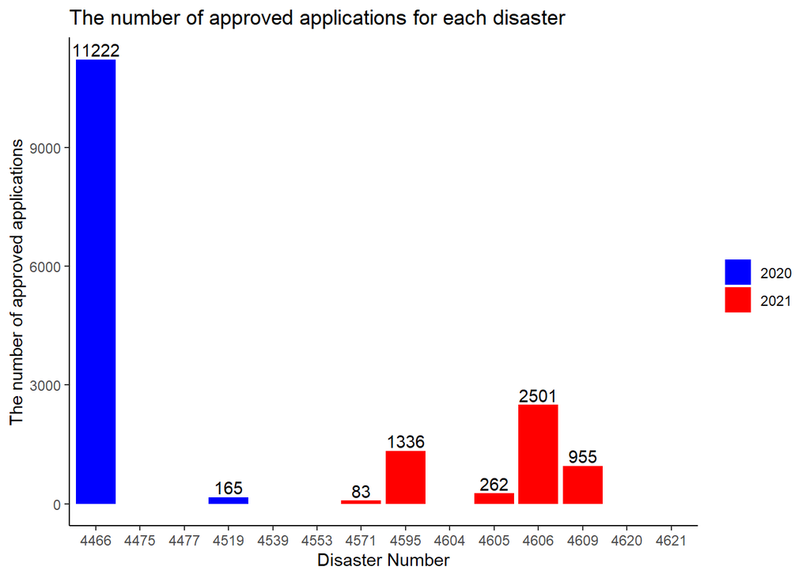

```r
ggplot(data = tidy_sum, aes(x = as.factor(disasterNumber), y = totalNumberIaApproved, fill = year)) +
  geom_bar(stat = "identity") +
  geom_text(aes(label = totalNumberIaApproved), position = position_dodge(width = 0.9), vjust = -0.25) +
  labs(x = "Disaster Number", y = "The number of approved applications", title = "The number of approved applications for each disaster") +
  scale_fill_manual(values = c("2020" = "blue", "2021" = "red")) +
  theme_classic() +
  theme(legend.title = element_blank())
```

From the description, we can ascertain that the fields totalAmountIhpApproved, totalAmountHaApproved, and totalAmountOnaApproved represent the same category of data, namely the amounts approved by different assistance programs.

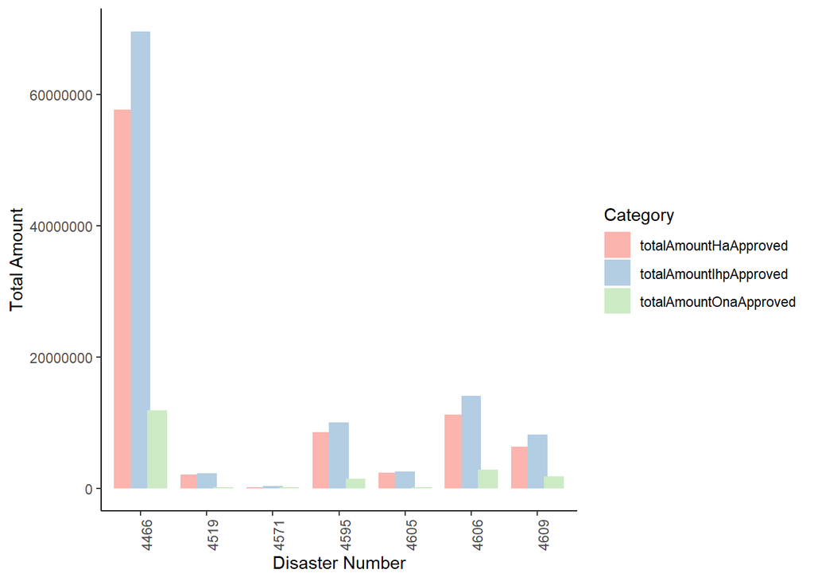

```r
totalA <- tidy_sum |>
  select(c(disasterNumber, totalAmountHaApproved, totalAmountIhpApproved, totalAmountOnaApproved, year)) |>
  na.omit()

totalA_long <- totalA |>
  select(disasterNumber, totalAmountHaApproved, totalAmountIhpApproved, totalAmountOnaApproved) |>
  pivot_longer(
    cols = -disasterNumber,
    names_to = "Category",
    values_to = "Amount"
  ) |>
  mutate(Category = factor(Category, levels = c("totalAmountHaApproved", "totalAmountIhpApproved", "totalAmountOnaApproved")))

ggplot(totalA_long, aes(x = factor(disasterNumber), y = Amount, fill = Category)) +
  geom_bar(stat = "identity", position = position_dodge(width = 0.75)) +
  scale_fill_brewer(palette = "Pastel1") +
  labs(x = "Disaster Number", y = "Total Amount", fill = "Category") +
  theme_classic() +
  theme(axis.text.x = element_text(angle = 90, hjust = 1))
```